# STAT 5702: Final Project

## Introduction

#### Motivation

Indego is the de facto bike sharing network in Philadelphia. It has become a popular, more eco-friendly alternative for short trips across the city since launching in late April of 2015. However, little has been done to analyze the publicly available data associated with Indego. Thus, we think it would be beneficial to the public if we quantify and assess several pertinent features and patterns related to Indego, generating insights on how the bike sharing network is utilized across the city. More specifically, we want to more closely study and answer questions related to the following four themes:

- Station usage (usage rate, peak periods, popular rental/return stations, etc.)
- Daily traffic (popular routes, volume across different sections, travel patterns, etc.)
- Trip durations (length of trips, median rental/return time, etc.)
- User profiles (type of passholders, frequency of round-trips, seasonality, etc.)

Each of the above four features will be explained in finer details in subsequent sections. To realize this objective, we have created static plots (shown in this notebook) to describe salient themes as well as a Shiny app ([Github](https://github.com/masonsun/gr5702-proj)), which also contains real-time status updates of all Indego stations across Philadelphia. We will also provide instructions on runnning our app further down in our report.

Our objective starting out was to examine bike share programs in the most densely populated cities across the eastern United States, mainly via exploratory data analysis and visualization techinques. We initially considered NYC’s Citibike as a promising candidate, but it has already been extensively analyzed (see [Todd Schneider’s blogpost](http://toddwschneider.com/posts/a-tale-of-twenty-two-million-citi-bikes-analyzing-the-nyc-bike-share-system/) for an excellent example). The marginal returns of analyzing such a dataset are thus minimal, if not, nil. As a result, we decided on Philadelphia, primarliy for two reasons: it is the second largest city satisfying our predefined criteria (after NYC), and also has a relatively new bike share program. Thus, we thought the Indego dataset would be an ideal choice. It would also be interesting to use our dataset to compare and contrast New York and Philadelphia’s bike share programs.

#### Data Source

The dataset is publicly available on [Indego’s website](https://www.rideindego.com/about/data/). It can be found by clicking the *About* panel and then selecting *Data*. All quarterly data are listed under the section *The Data*, in which each station’s information is available through the *Station Table* hyperlink. In addition, real-time data used in our Shiny app is available under the section *Indego Station Status* via the GeoJSON hyperlink.

## Team

1. Kejia Shi (ks3403): data processing, exploratory data analysis, visualization (static and Shiny plots), writing/editing report.
2. Mason Sun (zs2321): data processing, exploratory data analysis, developing front/backend of Shiny app, writing/editing report.
3. Hung-Shi Lin (hl2997): proofread code.

## Analysis of Data Quality

#### Quarterly data

For quarterly data, we had seven files in total, each representing data between Q2 of 2015 and Q4 of 2016, inclusively. Each contained the same columns:

- trip_id (unique identifier of a bike trip)
- duration (length of trip in seconds or minutes calculated by check-in and check-out time)
- start_time (clock start time and calendar date)
- end_time (clock end time and calenar date)
- start_station_id (unique identifier of starting station)
- start_lat (latitude of starting station)
- start_lon (longitude of starting station)
- end_station_id (unique identifier of end station)
- end_lat (latitude of end station)
- end_lon (longitude of end station)
- bike_id (unique identifier of the bike used during the trip)
- plan_duration (type of pass by number of days, e.g. thirty-day pass is shown as 30)
- trip_route_category (round trip or one-way)
- passholder_type (walkup, IndegoFlex, or Indego30)

We combined these into one data frame (called *df*) using the code as follows. The description of our preprocessing methods are embedded as comments in the code chunk below. Please see them for more detailed explanations.

```r
### read in quarterly data ###
Y16Q4 <- read.csv("data/Indego_Trips_2016Q4.csv", header=T)
Y16Q3 <- read.csv("data/Indego_Trips_2016Q3.csv", header=T)
Y16Q2 <- read.csv("data/Indego_Trips_2016Q2.csv", header=T)
Y16Q1 <- read.csv("data/Indego_Trips_2016Q1.csv", header=T)
Y15Q4 <- read.csv("data/Indego_Trips_2015Q4.csv", header=T)
Y15Q3 <- read.csv("data/Indego_Trips_2015Q3.csv", header=T)
Y15Q2 <- read.csv("data/Indego_Trips_2015Q2.csv", header=T)

### preprocessing ###
# select currently active stations from most recent quarterly dataset
station_loc <- Y16Q4 %>% dplyr::select(start_station_id, start_lat, start_lon) %>% unique
# create a dataframe that includes the relevant columns for all active stations by left joining on the active stations and all stations, ignoring any rows that contain missing values
station_loc <- dplyr::left_join(station_loc, indego_stations, by = c("start_station_id" = "Station.ID")) %>% na.omit %>% .[, -6]
# rename columns of dataframe
colnames(station_loc) <- c("id", "lat", "long", "name", "date")
# remove whitespaces in the date column
station_loc$date = trim(station_loc$date %>% as.character())

# below are two auxiliary fuction to parse the start/end time and date of each trip, which displays them as a single string. We partition them into separate columns that now display year, month, day, hour, minutes, and date (YYYY-MM-DD).

# for quarters of 2015
parseTime_15 <- function(df) {
  df$s_hour <- format(as.POSIXct(strptime(df$start_time,"%m/%d/%y %H:%M",tz="")) ,format = "%H")
  df$s_min <- format(as.POSIXct(strptime(df$start_time,"%m/%d/%y %H:%M",tz="")) ,format = "%M")
  df$e_hour <- format(as.POSIXct(strptime(df$end_time,"%m/%d/%y %H:%M",tz="")) ,format = "%H")
  df$e_min <- format(as.POSIXct(strptime(df$end_time,"%m/%d/%y %H:%M",tz="")) ,format = "%M")
  df$year <- format(as.POSIXct(strptime(df$start_time,"%m/%d/%y %H:%M",tz="")) ,format = "%Y")
  df$month <- format(as.POSIXct(strptime(df$start_time,"%m/%d/%y %H:%M",tz="")) ,format = "%m")
  df$day <- format(as.POSIXct(strptime(df$start_time,"%m/%d/%y %H:%M",tz="")) ,format = "%d")
  df$date <- format(as.POSIXct(strptime(df$start_time,"%m/%d/%y %H:%M",tz="")) ,format = "%Y-%m-%d")
  return(df)
}

# for quarters of 2016, which are defined differently from 2015
parseTime_16 <- function(df) {
  df$s_hour <- format(as.POSIXct(strptime(df$start_time,"%m/%d/%Y %H:%M",tz="")) ,format = "%H")
  df$s_min <- format(as.POSIXct(strptime(df$start_time,"%m/%d/%Y %H:%M",tz="")) ,format = "%M")
  df$e_hour <- format(as.POSIXct(strptime(df$end_time,"%m/%d/%Y %H:%M",tz="")) ,format = "%H")
  df$e_min <- format(as.POSIXct(strptime(df$end_time,"%m/%d/%Y %H:%M",tz="")) ,format = "%M")
  df$year <- format(as.POSIXct(strptime(df$start_time,"%m/%d/%Y %H:%M",tz="")) ,format = "%Y")
  df$month <- format(as.POSIXct(strptime(df$start_time,"%m/%d/%Y %H:%M",tz="")) ,format = "%m")
  df$day <- format(as.POSIXct(strptime(df$start_time,"%m/%d/%Y %H:%M",tz="")) ,format = "%d")
  df$date <- format(as.POSIXct(strptime(df$start_time,"%m/%d/%Y %H:%M",tz="")) ,format = "%Y-%m-%d")
  return(df)
}

# pass into respective auxiliary functinos
Y15Q2 <- parseTime_15(Y15Q2)
Y15Q3 <- parseTime_15(Y15Q3)
Y15Q4 <- parseTime_15(Y15Q4)
Y16Q1 <- parseTime_16(Y16Q1)
Y16Q2 <- parseTime_16(Y16Q2)
Y16Q3 <- parseTime_16(Y16Q3)
Y16Q4 <- parseTime_16(Y16Q4)

# standardize duration into units of seconds
# also removes columns not needed in subsequent analyses
dataClean <- function(df) {
  df$duration <- df$duration / 60
  df[, -c(1, 3, 4, 6, 7, 9, 10, 12)]
}
df <- dataClean(df)

# combine all quarterly data into a single data frame called df
df <- rbind(Y15Q2, Y15Q3, Y15Q4, Y16Q1, Y16Q2, Y16Q3, Y16Q4)
# remove individual dataframes
rm(Y15Q2, Y15Q3, Y15Q4, Y16Q1, Y16Q2, Y16Q3, Y16Q4)
```

During our initial exploration of the dataset, we realized some of the respective datasets for the quarterly data contained missing values, which would imply that our final dataframe also contains missing values. We thus try to qualitatively visualize these features, show below:

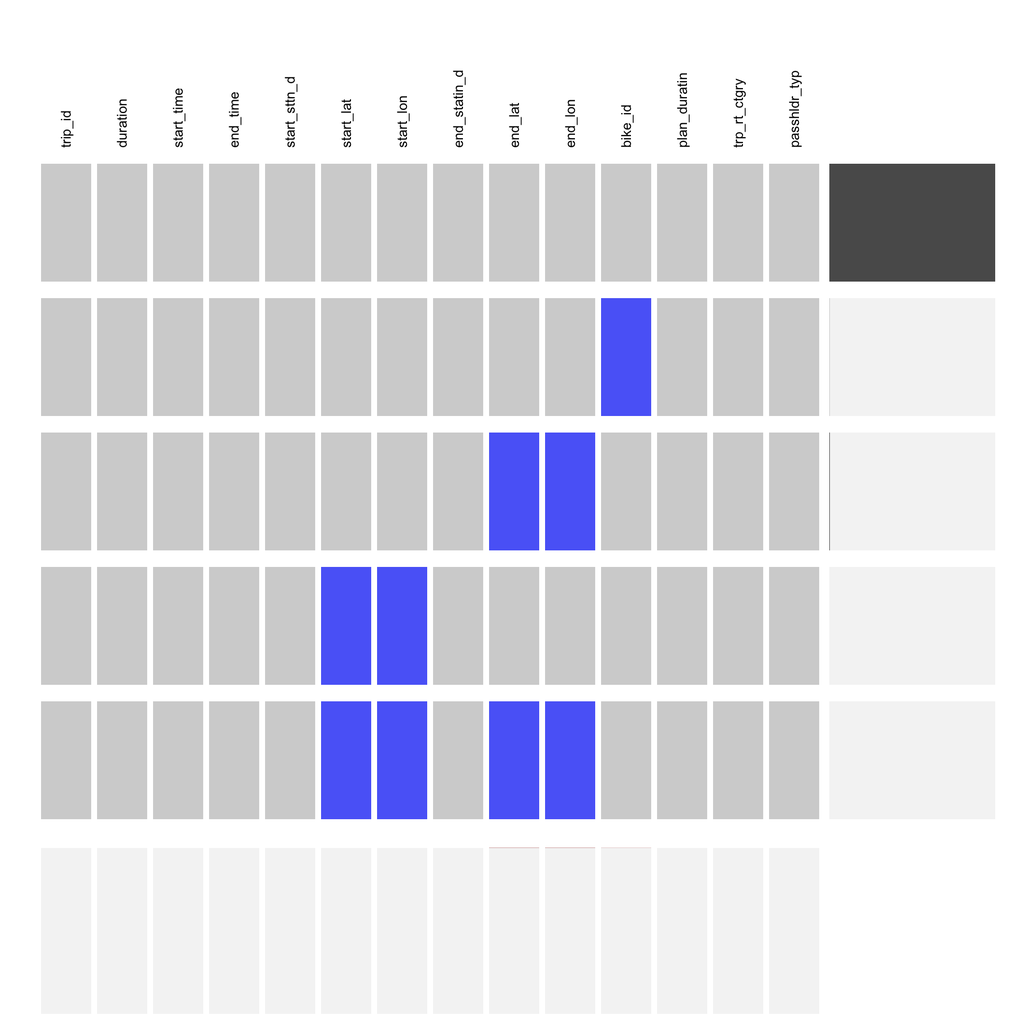

```r
# ignore columns after passholder_type (col_num = 14) as subsequent columns are defined by us.
library(extracat)
visna(df[,c(1:14)])
```

```r
missing_table = table(is.na(df))
```

```r
cat("Percentage of missing entries:", missing_table[2]/sum(missing_table)*100)
```

```
Percentage of missing entries: 0.01720519
```

We see that the proportion of missing values is miniscule relative to our whole dataset (approximately 0.0172%). Moreover, they are all related to latitude and longitude data as well as the bike ID. If need be, we can infer the latitude and longitude from the station name or station ID, but we actively chose to ignore rows corresponding to these missing values since we cannot explicate why these values are missing. We thus choose to ignore them altogether.

#### Indego stations data

For the data detailing the information of each station (indego_stations.csv), we had to perform a bit of data preprocessing to get it into an ideal format. The data contained the columns as follows:

- Station ID (unique identifier of a Indego station)
- Station Name (name of corresponding Indego station, usually a street address)
- Go live date (the date that the station started operations)
- Status (its current status, either active or inactive)

There were many leading and trailing whitespaces in the *Station Name* column, so performed the following to remove these unneeded characters:

```r
# load stations data
indego_stations <- read.csv("../data/indego_stations.csv", header=T)
# a function that removes leading and trailing white spaces of a given string
trim <- function (x) gsub("^\\s+|\\s+$", "", x)
# remove whitespaces surrounding each entry in the column of Station.Name
indego_stations$Station.Name <- trim(indego_stations$Station.Name)
```

There were no missing values in this table, so we do not provide plots related to this here.

#### GeoJSON

For real-time status updates of Indego stations, we use the semi-structured [GeoJSON dataset](https://www.rideindego.com/stations/json/) provided by Indego. We allow the user to manually refresh our Shiny app, in which we call the GeoJSON file in real-time to get a visualization update (more specific details in subsequent sections). We used the R packpage [geojsonio](https://cran.r-project.org/web/packages/geojsonio/index.html) to unpack and transform this data into a workable format as follows:

```r
library(geojsonio)
station_status <- fromJSON("https://gbfs.bcycle.com/bcycle_indego/station_status.json")
```

## Main analysis

In this main section, we present our findings of different facets pertaining to the Indego dataset. We subdivide our analysis into four interrelated sections: station usage, daily traffic, trip duration, and user profiles, in that particualr order. We will walk the reader through our thought process and findings, and finally present some concluding remarks.

#### Station usage

In this section, we examine the usage rate among the different Indego stations across Philadelphia. We motivate our analysis from a holistic perspective towards more granular analysis. This structural layout also holds true for subsequent sections. With that in mind, let us first patterns related to some of the more popular Indego stations. We subdivide our analysis to that of rental and return stations, which reflect popular starting and terminal destinations that people elect to choose in Philadelphia.

```r
# Popular Stations - histogram
library(gridExtra)
popular_station <- df %>% group_by(year, month, start_station_id) %>% summarize(rental = n())
colnames(popular_station)[3] <- "id"
popular_station$id <- as.character(popular_station$id)
foo <- df %>% group_by(year, month, end_station_id) %>% summarize(return = n())
colnames(foo)[3] <- "id"
foo$id <- as.character(foo$id)
popular_station <- popular_station %>% full_join(foo, by = c("id" = "id", "year" = "year", "month" = "month"))
rm(foo)
popular_station <- tidyr::gather(popular_station, type, count, c(4,5))
colnames(popular_station)[3] <- "id"
popular_station[is.na(popular_station)] <- 0
popular_station <- popular_station[popular_station$id!="#N/A",]
station_loc$id <- as.character(station_loc$id)
reduced_station <- popular_station %>% left_join(station_loc, by=c("id"="id")) %>% na.omit
reduced_station$quarter <- (as.numeric(as.character(reduced_station$month)) - 1) %/% 3 + 1
reduced_station <- reduced_station %>% group_by(id, name, lat, long, type, year, quarter) %>% summarize(count = sum(count))
# Earliest quarter: 2015Q2, Latest quarter: 2016Q4
reduced_station$year <- as.numeric(reduced_station$year)
rs_first_rental <- reduced_station[reduced_station$year==2015&reduced_station$quarter==2&reduced_station$type=="rental",]
rs_last_rental <- reduced_station[reduced_station$year==2016&reduced_station$quarter==4&reduced_station$type=="rental",]
rs_first_return <- reduced_station[reduced_station$year==2015&reduced_station$quarter==2&reduced_station$type=="return",]
rs_last_return <- reduced_station[reduced_station$year==2016&reduced_station$quarter==4&reduced_station$type=="return",]
rs_first_rental <- rs_first_rental[order(-rs_first_rental$count),][1:10,]
rs_last_rental <- rs_last_rental[order(-rs_last_rental$count),][1:10,]
rs_first_return <- rs_first_return[order(-rs_first_return$count),][1:10,]
rs_last_return <- rs_last_return[order(-rs_last_return$count),][1:10,]
rs_first_rental$name <- factor(rs_first_rental$name, levels = rs_first_rental$name[order(rs_first_rental$count)])
rs_last_rental$name <- factor(rs_last_rental$name, levels = rs_last_rental$name[order(rs_last_rental$count)])
rs_first_return$name <- factor(rs_first_return$name, levels = rs_first_return$name[order(rs_first_return$count)])
rs_last_return$name <- factor(rs_last_return$name, levels = rs_last_return$name[order(rs_last_return$count)])
p1 <- ggplot(rs_first_rental, aes(x = name, y = count)) +
  geom_bar(stat = 'identity', color="blue", fill="blue") +
  geom_text(aes(label=count), hjust=-0.05, size=2.5) +
  coord_flip() +
  ggtitle("Most Popular Rental Station 2015Q2") +
  xlab("Frequency") +
  ylab("Station") +
  scale_color_fivethirtyeight("cyl") +
  theme_fivethirtyeight() +
  theme(plot.margin = unit(c(0.5,0.5,0.5,0.5), "cm"))
p2 <- ggplot(rs_last_rental, aes(x = name, y = count)) +
  geom_bar(stat = 'identity', color="blue", fill="blue") +
  geom_text(aes(label=count), hjust=-0.05, size=2.5) +
  coord_flip() +
  ggtitle("Most Popular Rental Station 2016Q4") +
  xlab("Frequency") +
  ylab("Station") +
  scale_color_fivethirtyeight("cyl") +
  theme_fivethirtyeight() +
  theme(plot.margin = unit(c(0.5,0.5,0.5,0.5), "cm"))
p3 <- ggplot(rs_first_return, aes(x = name, y = count)) +
  geom_bar(stat = 'identity', color="blue", fill="blue") +
  geom_text(aes(label=count), hjust=-0.05, size=2.5) +
  coord_flip() +
  ggtitle("Most Popular Return Station 2015Q2") +
  xlab("Frequency") +
  ylab("Station") +
  scale_color_fivethirtyeight("cyl") +
  theme_fivethirtyeight() +
  theme(plot.margin = unit(c(0.5,0.5,0.5,0.5), "cm"))
p4 <- ggplot(rs_last_return, aes(x = name, y = count)) +
  geom_bar(stat = 'identity', color="blue", fill="blue") +
  geom_text(aes(label=count), hjust=-0.05, size=2.5) +
  coord_flip() +
  ggtitle("Most Popular Return Station 2016Q4") +
  xlab("Frequency") +
  ylab("Station") +
  scale_color_fivethirtyeight("cyl") +
  theme_fivethirtyeight() +
  theme(plot.margin = unit(c(0.5,0.5,0.5,0.5), "cm"))
p1 <- ggplot_gtable(ggplot_build(p1))
p2 <- ggplot_gtable(ggplot_build(p2))
p3 <- ggplot_gtable(ggplot_build(p3))
p4 <- ggplot_gtable(ggplot_build(p4))
maxWidth = grid::unit.pmax(p1$widths[2:3], p2$widths[2:3], p3$widths[2:3], p4$widths[2:3])
p1$widths[2:3] <- maxWidth
p2$widths[2:3] <- maxWidth
p3$widths[2:3] <- maxWidth
p4$widths[2:3] <- maxWidth
```

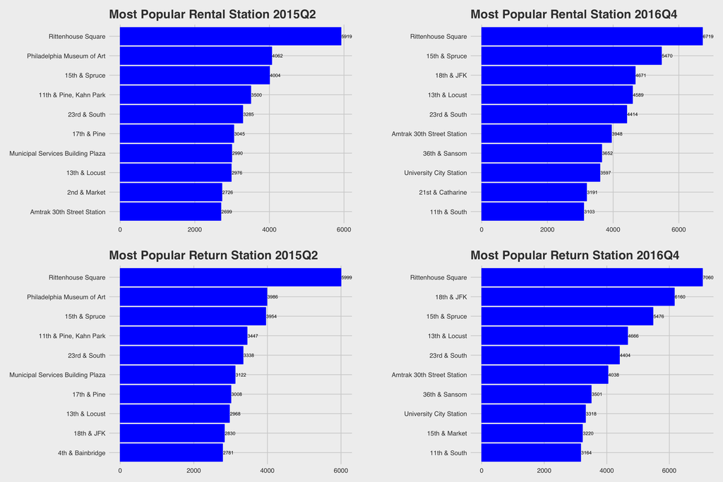

```r
# Plot histograms for selected quarters
grid.arrange(p1, p2, p3, p4, heights = c(3, 3))
```

In the above graph, we see that the most popular stations are somewhat invariant to time. We chose the first and latest quarters to determine most popular rental and return stations. In all cases, the most popular rental and return station was [Rittenhouse Square](https://en.wikipedia.org/wiki/Rittenhouse_Square). This is intuitive as it is not only a popular tourist destination, being hailed as “one of the finest urban public spaces in the United States,” (at least according to Wikipedia) but it is also in close proximity to the epicenter of Philadelphia. More specifically, in Q2 of 2015, the top five most popular rental and return stations were all the same, with the exact same ranking. Thus, it would seem that there is no preference for dropoff or pickup stations, but simply hubs for bike users. In Q4 of 2016, we observe many of the same return and and rental stations, but differences exist. For instance, Philadelphia Museum of Art (PMOA) is no longer in the top ten most popular return or rental stations whereas University City station is, which was not in Q2 of 2015. These variability are difficult to explain based on the dataset alone, but we surmise a couple of possible causes. First, the demographic of Indego users has shifted over time (from intrigued users to a those using it for routine trips). Second, seasonality may affect popular rental/return stations. There is a larger tourist cohort during the summer so that may be why PMOA is so high up in the rankings for Q2 of 2015. These are all conjectural, and it may serve as an interesting avenue for further exploration. However this is beyond the scope of our project.

We postulate that the popularity of certain stations across time is due to the fact they are in areas of heavy pedestrian traffic (e.g. city centers), and they are in close proximity to one another but outside comfortable walking range. We thus put this idea to the test by considering spatial patterns and distances amongst these more popular stations.

```r
# Popular stations - maps
rs_first_return$type <- "Return"
rs_last_return$type <- "Return"
rs_first_rental$type <- "Rental"
rs_last_rental$type <- "Rental"
Q2Y15 <- rbind(rs_first_return, rs_first_rental)
Q4Y16 <- rbind(rs_last_return, rs_last_rental)
pal <- colorFactor(c("navy", "red"), domain = c("Return", "Rental"))
# Purple: popular for both return and rental
# Red: only for rental
# Blue: only for return
# Size: total frequency within the quarter
# for Q2 of 2015
leaflet(Q2Y15) %>%
  addTiles() %>%
  addProviderTiles('CartoDB.Positron') %>%
  setView(lng=-75.163763, lat=39.952568, zoom = 13) %>%
  addCircleMarkers(
    radius = ~sqrt(count)/10,
    color = ~pal(type),
    stroke = FALSE, fillOpacity = 0.5,
    popup = ~name
  )
```

[interactive chart not shown]

```r
# for Q4 of 2016
leaflet(Q4Y16) %>%
  addTiles() %>%
  addProviderTiles('CartoDB.Positron') %>%
  setView(lng=-75.163763, lat=39.952568, zoom = 13) %>%
  addCircleMarkers(
    radius = ~sqrt(count)/10,
    color = ~pal(type),
    stroke = FALSE, fillOpacity = 0.5,
    popup = ~name
  )
```

[interactive chart not shown]

#### Daily traffic

```r
# 2. Peak Periods (group by hour, weekdays/weekends, season)
# 2.1 Weekdays/weekends histogram of start (rental) hours for all stations in 2016Q2
library(lubridate)
Q2Y16 <- df[df$year==2016 & df$month %in% c("04","05","06"), ]
Q2Y16$day_type <- chron::is.weekend(Q2Y16$date)
Q2Y16$day_type <- ifelse(Q2Y16$day_type == 1, "Weekends", "Weekdays")
n_wknds <- length(unique(Q2Y16[Q2Y16$day_type=="Weekends",14]))
n_wkdys <- length(unique(Q2Y16[Q2Y16$day_type=="Weekdays",14]))
wknds_peak <- Q2Y16[Q2Y16$day_type=="Weekends",] %>% group_by(s_hour,day_type) %>% summarize(rental_freq = n()/n_wknds)
wkdys_peak <- Q2Y16[Q2Y16$day_type=="Weekdays",] %>% group_by(s_hour,day_type) %>% summarize(rental_freq = n()/n_wkdys)
peak <- rbind(wknds_peak, wkdys_peak)
rm(wknds_peak, wkdys_peak)
peak$s_hour <- as.numeric(as.character(peak$s_hour))
foo1 <- c(0,4,8,12,16,20)
foo2 <- c("12am","4am","8am","12pm","4pm","8pm")
```

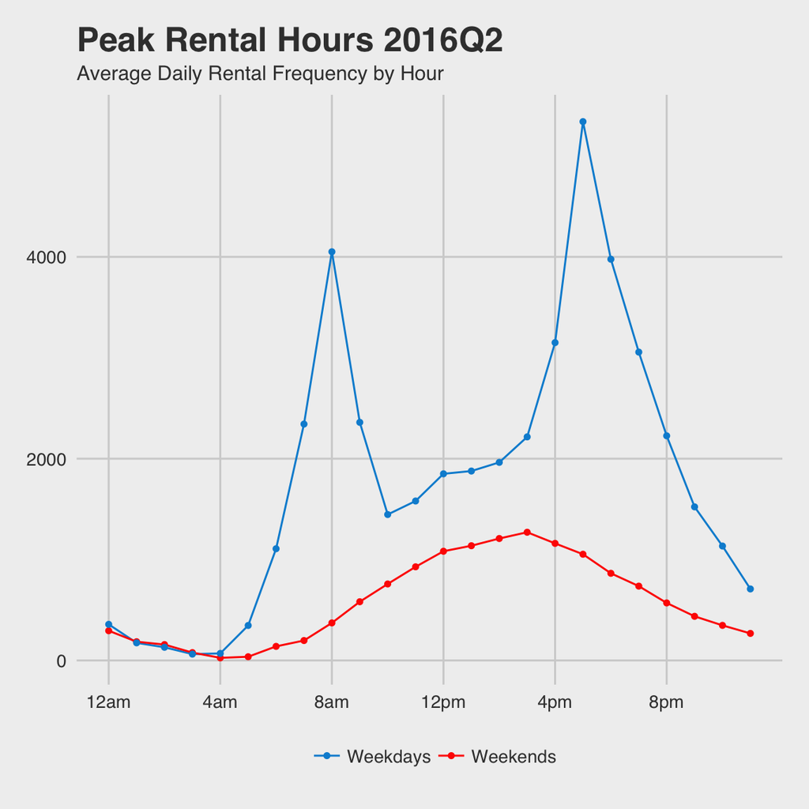

```r
ggplot(peak, aes(s_hour, rental_freq)) +
  geom_line(aes(color=day_type)) +
  geom_point(size = 1.1, aes(color=day_type)) +
  labs(title="Peak Rental Hours 2016Q2",
       subtitle="Average Daily Rental Frequency by Hour") +
  scale_color_fivethirtyeight("") +
  theme_fivethirtyeight() +
  theme(plot.margin = unit(c(0.5,0.5,0.5,0.5), "cm")) +
  scale_x_continuous(breaks = foo1, labels = foo2)
```

```r
# 2.2 Month aggregation of results
quarter_aggr <- df
#quarter_aggr$quarter <- (as.numeric(as.character(quarter_aggr$month)) - 1) %/% 3 + 1
quarter_aggr$day_type <- chron::is.weekend(quarter_aggr$date)
quarter_aggr$day_type <- ifelse(quarter_aggr$day_type == 1, "Weekends", "Weekdays")
quarter_aggr <- quarter_aggr %>% select(year, month, date, day_type)
quarter_aggr <- quarter_aggr %>% group_by(date, year, month, day_type) %>% summarise(count=n())
quarter_aggr <- quarter_aggr %>% group_by(year, month, day_type) %>% summarise(average=mean(count))
quarter_aggr$no <- (0:(nrow(quarter_aggr)-1)) %/% 2 + 1
foo1 <- seq(1,21,by=3)
foo2 <- c("Apr 2015","Jul 2015","Oct 2015", "Jan 2016", "Apr 2016","Jul 2016","Oct 2016")
```

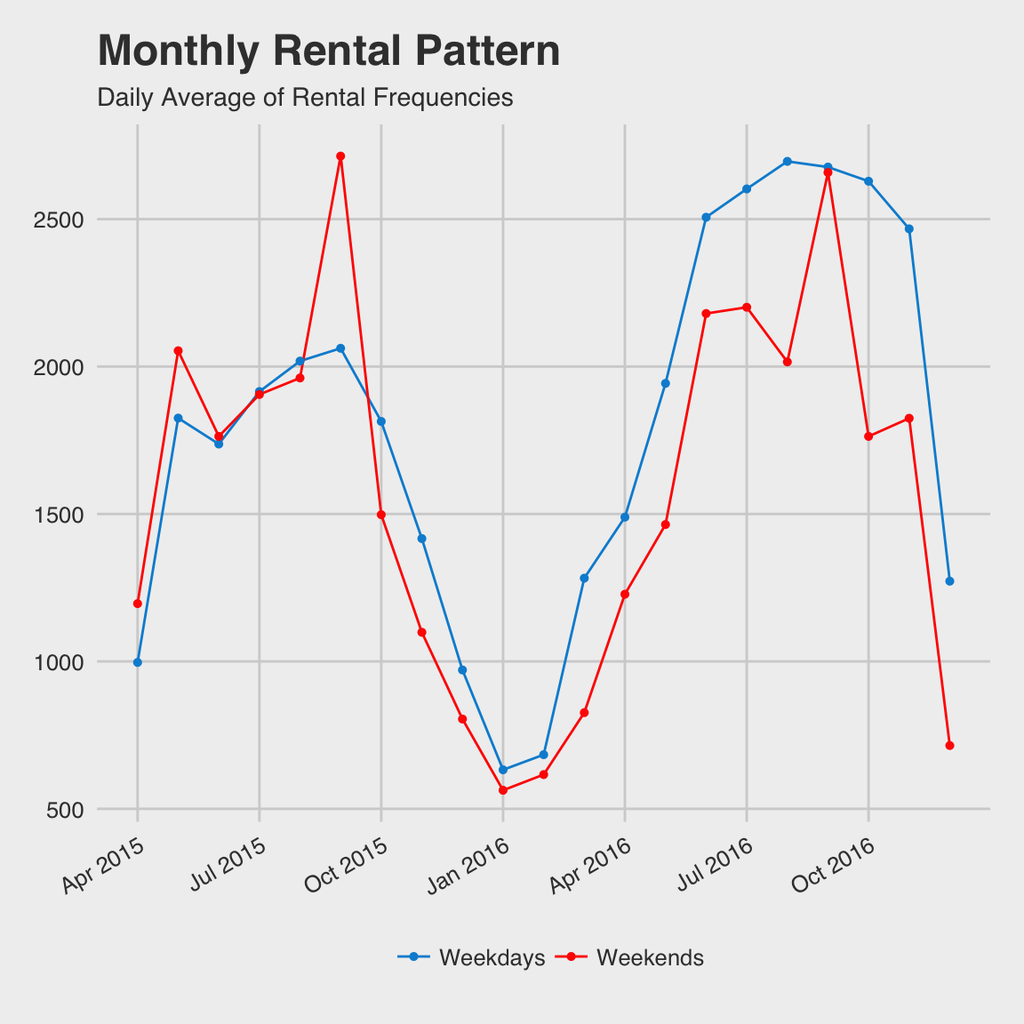

```r
ggplot(quarter_aggr, aes(no, average)) +
  geom_line(aes(color=day_type)) +
  geom_point(size = 1.1, aes(color=day_type)) +
  labs(title="Monthly Rental Pattern",
       subtitle="Daily Average of Rental Frequencies") +
  scale_color_fivethirtyeight("") +
  theme_fivethirtyeight() +
  theme(plot.margin = unit(c(0.5,0.5,0.5,0.5), "cm")) +
  scale_x_continuous(breaks = foo1, labels = foo2) +
  theme(axis.text.x = element_text(angle = 30, hjust = 1))
```

It is important to note that one of the more glaring deficiencies of our raw dataset is the lack of historical data; we only have data from April 2015 onwards. It thus makes it more difficult to draw conclusive remakrs regarding yearly or even seasonal patterns that require data over longer time periods. Nonetheless, several important trends can still be observed over the time period for which the dataset is available.

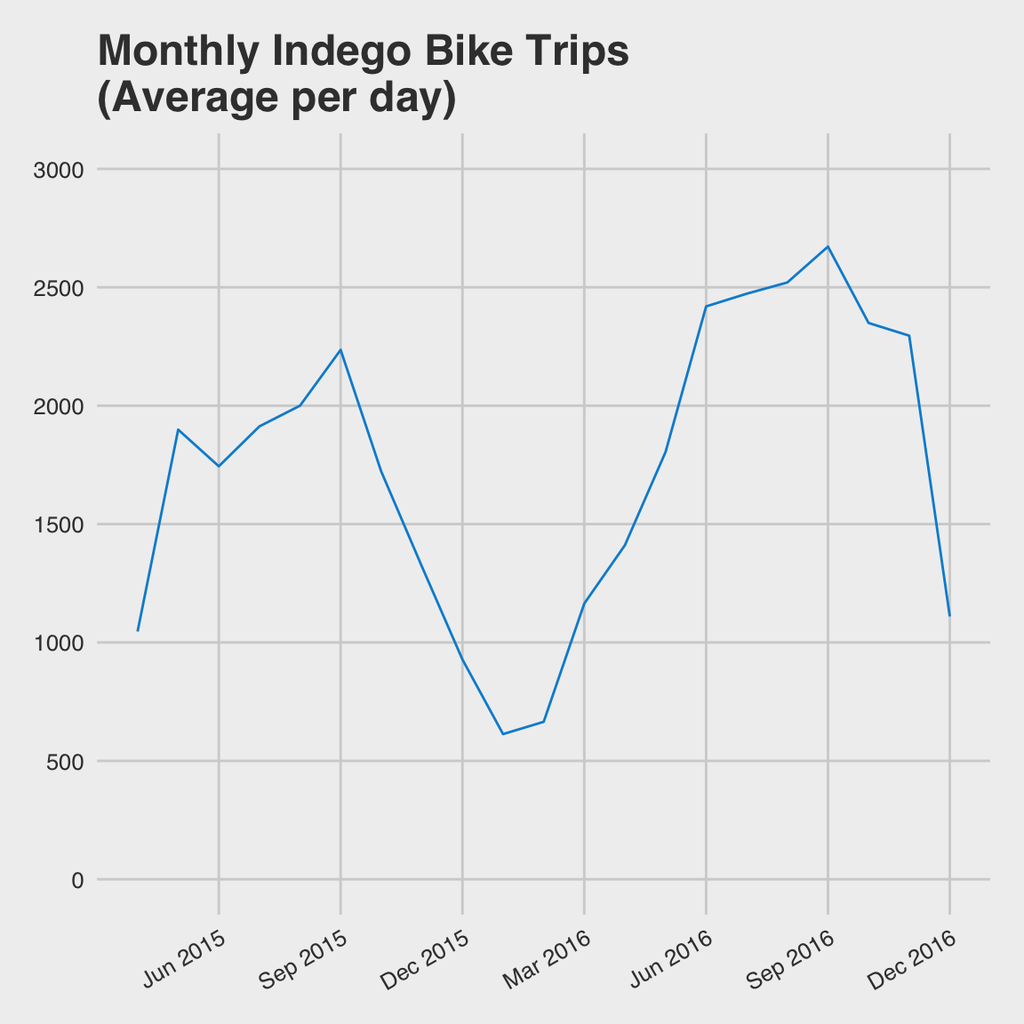

```r
# Monthly Bike Trips
df_count_by_month <- df %>% group_by(year, month) %>% summarize(count = n())
df_average_by_month <- df %>% group_by(year, month, day) %>% summarize(count = n())
df_average_by_month <- df_average_by_month %>% group_by(year, month) %>% summarize(avg = mean(count))
df_count_by_month$date <- zoo::as.yearmon(paste(df_count_by_month$year, df_count_by_month$month), "%Y %m")
df_count_by_month$average <- df_average_by_month$avg
df_count_by_month$no <- 1:nrow(df_count_by_month)
df_count_by_month <- df_count_by_month[,-c(1,2)]
rm(df_average_by_month)
df_count_by_month <- tidyr::gather(df_count_by_month, type, value, c(1,3))
foo1 <- c(0, 500, 1000, 1500, 2000, 2500, 3000)
foo2 <- c(3, 6, 9, 12, 15, 18, 21)
ggplot() +
  geom_line(aes(no, value, color="blue"), df_count_by_month[df_count_by_month$type=="average",]) +
  geom_point(size = 1.1) +
  ggtitle("Monthly Indego Bike Trips\n(Average per day)") +
  xlab("Month") +
  ylab("Count") +
  scale_color_fivethirtyeight("cyl") +
  theme_fivethirtyeight() +
  theme(axis.text.x = element_text(angle = 30, hjust = 1),legend.position="none") +
  scale_y_continuous(limits = c(0, 3000), breaks = foo1) +
  scale_x_continuous(breaks = foo2, labels = df_count_by_month$date[foo2]) +
  theme(plot.margin = unit(c(0.5,0.5,0.5,0.5), "cm"))
```

Based on the above findings, we can say with a certain level of confidence that the volume of bike trips is an important indicator of Indego’s utility rate over different cross-sections of time. However, it does little to tell us how (not how much) Indego is being utilized. With this in mind, we motivate our next portion of analysis.

Since the inherent purpose of bike share networks are to mediate relatively short commutes, we want to examine the length of each trip. We surmise that shorter trips (0-30 minutes) should be the ideal range since anything beyond that is simply exercise and other transportation methods become increasingly more appealing. We consequently explore features related to the length of bike rides next.